# The Ten Biggest Storms and their Impact in the Health and Economy of the Population: 1950:2011

Luis Urbina

Wednesday, May 20, 2015

## I SYNOPSIS

.

Storm Data is an official publication of the NOAA, and it documents the occurrence of sifnificant weather phenomena causing loss of life, injuries, and significant property damage. Based on the Storm Data database covering the years from 1950 to 2011, the purpose of this report is to determine the severe weather events that cause the biggest harm to the population health. It also is determine the events that have the biggest impact in the economic aspect.

.

## II DATA PROCESSING

.

### 2.1) Loading and preprocessing the data

The given the database file ‘repdata-data-StormData.csv.bz2’, is loaded and the dataset is named **data**. In order to sanitize the database, blank cells are replaced with the NA value.

```r
    data = read.csv(bzfile('repdata-data-StormData.csv.bz2'),
                    header=T, na.strings=c("", "NA"))
```

. It is also necessary to eliminate duplicate rows if they exist.

```r
    data <- data[,-37]
    data <- unique(data)
```

.

### 2.2) Exploring the dataset behavior.

```r
    str(data)
```

```
## 'data.frame':    899154 obs. of  36 variables:
##  $ STATE__   : num  1 1 1 1 1 1 1 1 1 1 ...
##  $ BGN_DATE  : Factor w/ 16335 levels "1/1/1966 0:00:00",..: 6523 6523 4242 11116 2224 2224 2260 383 3980 3980 ...
##  $ BGN_TIME  : Factor w/ 3608 levels "00:00:00 AM",..: 272 287 2705 1683 2584 3186 242 1683 3186 3186 ...
##  $ TIME_ZONE : Factor w/ 22 levels "ADT","AKS","AST",..: 7 7 7 7 7 7 7 7 7 7 ...
##  $ COUNTY    : num  97 3 57 89 43 77 9 123 125 57 ...
##  $ COUNTYNAME: Factor w/ 29600 levels "5NM E OF MACKINAC BRIDGE TO PRESQUE ISLE LT MI",..: 13512 1872 4597 10591 4371 10093 1972 23872 24417 4597 ...
##  $ STATE     : Factor w/ 72 levels "AK","AL","AM",..: 2 2 2 2 2 2 2 2 2 2 ...
##  $ EVTYPE    : Factor w/ 985 levels "   HIGH SURF ADVISORY",..: 834 834 834 834 834 834 834 834 834 834 ...
##  $ BGN_RANGE : num  0 0 0 0 0 0 0 0 0 0 ...
##  $ BGN_AZI   : Factor w/ 34 levels "  N"," NW","E",..: NA NA NA NA NA NA NA NA NA NA ...
##  $ BGN_LOCATI: Factor w/ 54428 levels "- 1 N Albion",..: NA NA NA NA NA NA NA NA NA NA ...
##  $ END_DATE  : Factor w/ 6662 levels "1/1/1993 0:00:00",..: NA NA NA NA NA NA NA NA NA NA ...
##  $ END_TIME  : Factor w/ 3646 levels " 0900CST"," 200CST",..: NA NA NA NA NA NA NA NA NA NA ...
##  $ COUNTY_END: num  0 0 0 0 0 0 0 0 0 0 ...
```

[output cut: 22 more lines]

Official documents from NOAA indicates that the the variables **FATALITIES** and **INJURIES** are directly related with the populationn health harm caused for the storm events. They also indicate that the variables **PROPDMG**, **PROPDMGEXP**, **CROPDMG**, and **CROPDMGEXP** are directly related with the economic impact of the phenomenos ocurrency.

So, the research project is mainly oriented to find out the relation of those variables with the storm event type, the location and date of ocurrency. other minor details are not taken in consideration for the purpose of the research.

.

### 2.3) Exploring the variables of interest: people health harm

.

```r
    summary(data[,c(23,24)])
```

```
##    FATALITIES          INJURIES
##  Min.   :  0.0000   Min.   :   0.0000
##  1st Qu.:  0.0000   1st Qu.:   0.0000
##  Median :  0.0000   Median :   0.0000
##  Mean   :  0.0168   Mean   :   0.1554
##  3rd Qu.:  0.0000   3rd Qu.:   0.0000
##  Max.   :583.0000   Max.   :1700.0000
```

. Above is shown a summary of the main statistic characteristics of the **FATALITIES** and **INJURIES** variable. For the nature of the storm events, natural phenomenums, the nature of the distribution of these variables may be considered discrete.

With a median equal to zero and a mean very far away of the maximum value of the serie, for both variables, a lecture over the statistic summary indicates that both variables have a kind of chi distribution behavior.

Two ratios about the incidence of the biggest event over the variable population, the **fatalities ratio** and the **injuries ratio**, are calculated. These are indicators of the impact of the maximum number of fatalities and injuries caused for the biggest event over the total of fatalities and injuries caused for the total number of events.

```r
    max(data$FATALITIES) * 100 / sum(data$FATALITIES)
```

```
## [1] 3.865791
```

```r
    max(data$INJURIES) * 100 / sum(data$INJURIES)
```

```
## [1] 1.216806
```

So this research will conduct to determine the events with the biggest people health harm.

.

### 2.4) Histograma: Fatalities and Injuries variables.

The **histogram of fatalaties** in an event.

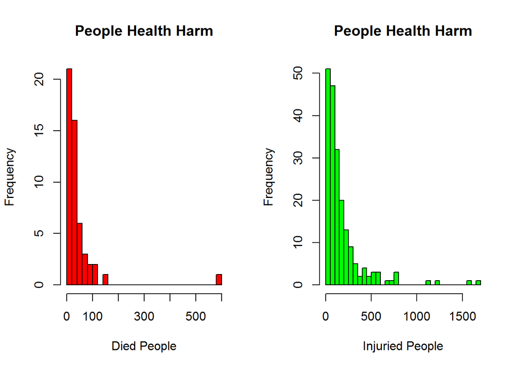

```r
    old.par <- par(mfrow=c(1, 2))
    hist(unique(data$FATALITIES), breaks=25, col='red',
            main="People Health Harm",
            xlab = 'Died People')
    hist(unique(data$INJURIES), breaks=25, col='green',
            main="People Health Harm",
            xlab = 'Injuried People')
```

```r
    par(old.par)
```

.

### 2.5) Exploring the variables of interest: economic impact

.

```r
    summary(data[,c(25,27)])
```

```
##     PROPDMG           CROPDMG
##  Min.   :   0.00   Min.   :  0.00
##  1st Qu.:   0.00   1st Qu.:  0.00
##  Median :   0.00   Median :  0.00
##  Mean   :  12.05   Mean   :  1.53
##  3rd Qu.:   0.50   3rd Qu.:  0.00
##  Max.   :5000.00   Max.   :990.00
```

A summary of the main statistic characteristics of the **PROPDMG** and the **CROPDMG** variables is shown above. The mean of the variables PROPDMG and CROPDMG, 12.06 and 1.527 respectively, the median with value equal to zero, and having the max value very far away (5000, 990 respectively), may indidates that the values of these variables may be following a chi square distribution.

It means that there are a lot of events with very low economic impact and a few storm events with high economic impact. Ratios about the cost impact of the biggest event over the total cost is calculated in the **property ratio** and the **crop ratio**. These are indicators of the impact of the maximum cost in property and crop damaged caused for the biggest event over the total of damage cost caused for the total number of events.

```r
    max(data$PROPDMG) * 100 / sum(data$PROPDMG)
```

```
## [1] 0.04613312
```

```r
    max(data$CROPDMG) * 100 / sum(data$CROPDMG)
```

```
## [1] 0.07197776
```

.

```r
    summary(data[,c(26,28)])
```

```
##    PROPDMGEXP       CROPDMGEXP
##  K      :422350   K      :279773
##  M      : 11268   M      :  1986
##  0      :   216   k      :    21
##  B      :    40   0      :    19
##  5      :    28   B      :     8
##  (Other):    84   (Other):     9
##  NA's   :465168   NA's   :617338
```

The **PROPDMGEXP** and **CROPDMGEXP** variables are multiplier factors helping to quantify the property and crop damage. Conversely to the other variables discussed above, these variables are of the factor type. They also have NA values and will requiere a specific treatment for using in the calculation process. Notice that the letter **B** means a billion multiplier, for example. The **NA** values will be replaced with a value equal to **1** in order to allow the quantification of the total cost of the damatge in both property and crop.

.

### 2.6) The Ten Biggest Storms

.

.

```r
tidy <- data[,c(2,5,7,8,23,24,25,26,27,28)]

dmg <- rbind(tidy[tidy$FATALITIES > 500 ,],
                tidy[tidy$INJURIES > 500 ,],
                tidy[tidy$PROPDMGEXP %in% "B",],
                tidy[tidy$CROPDMGEXP  %in% "B",])
#summary(dmg[,c(4,5,6,7,8,9)])
dim(dmg)
```

```
## [1] 66 10
```

. With this criteria is created a tidy dataset which include only the variable of interest. This criteria selection give to us a sub-data set with 66 registers including the storms and weather phenomenas that have caused more than 500 injured people, or more than 500 died people, or have caused damage in properties, or damage in crops in the order of billions of dollar.

.

### 2.7) Quantifying the total damage

. In order to quantified the impact of the above selected storms in the health and economy of the population, two variables are been created. The new **TOT.HARM** variable quantified the total number of persons that have suffer injured or fatalities caused by a storm. It adds the values of the FATALITIES and INJURIES variables.

```r
t <- dmg
t <- apply(t, 1, function(x){ifelse(x=="K", 1000, x)})
t <- apply(t, 1, function(x){ifelse(x=="M", 1000000, x)})
t <- apply(t, 1, function(x){ifelse(x=="B", 1000000000, x)})
t[is.na(t)] <- 1
t <- t(t)
t <- as.data.frame(t)

t$tot.harm <- as.numeric(levels(t$FATALITIES)[t$FATALITIES]) +
                as.numeric(levels(t$INJURIES)[t$INJURIES])

t$tot.dmg <- as.numeric(levels(t$PROPDMG)[t$PROPDMG]) *
            as.numeric(levels(t$PROPDMGEXP)[t$PROPDMGEXP]) +
            as.numeric(levels(t$CROPDMG)[t$CROPDMG]) *
            as.numeric(levels(t$CROPDMGEXP)[t$CROPDMGEXP])

summary(t[,c(11,12)])
```

```
##     tot.harm         tot.dmg
##  Min.   :   0.0   Min.   :0.000e+00
##  1st Qu.:   0.0   1st Qu.:3.022e+08
##  Median :   3.0   Median :1.500e+09
##  Mean   : 294.9   Mean   :4.854e+09
##  3rd Qu.: 581.5   3rd Qu.:4.019e+09
##  Max.   :1742.0   Max.   :1.150e+11
```

```r
top.harm <- t[order(-t$tot.harm),]
head(top.harm[,c(1,2,3,4,12,11)], n=10)
```

```
##                   BGN_DATE COUNTY STATE    EVTYPE   tot.dmg tot.harm
## 157885   4/10/1979 0:00:00    485    TX   TORNADO 2.500e+08     1742
## 223449    2/8/1994 0:00:00      0    OH ICE STORM 5.500e+07     1569
## 67884     6/9/1953 0:00:00     27    MA   TORNADO 2.500e+08     1318
## 862634   5/22/2011 0:00:00     97    MO   TORNADO 2.800e+09     1308
## 8626341  5/22/2011 0:00:00     97    MO   TORNADO 2.800e+09     1308
## 116011    4/3/1974 0:00:00     57    OH   TORNADO 2.500e+08     1186
## 68670     6/8/1953 0:00:00     49    MI   TORNADO 2.500e+07      901
## 860386   4/27/2011 0:00:00    125    AL   TORNADO 1.500e+09      844
## 8603861  4/27/2011 0:00:00    125    AL   TORNADO 1.500e+09      844
## 344159  10/17/1998 0:00:00     91    TX     FLOOD 5.005e+07      802
```

```r
top.dmg <- t[order(-t$tot.dmg),]
head(top.dmg[,c(1,2,3,4,11,12)], n=10)
```

```
##                   BGN_DATE COUNTY STATE            EVTYPE tot.harm
## 605953    1/1/2006 0:00:00     55    CA             FLOOD        0
## 577676   8/29/2005 0:00:00     40    LA       STORM SURGE        0
## 577675   8/28/2005 0:00:00     34    LA HURRICANE/TYPHOON        0
## 581535   8/29/2005 0:00:00     80    MS       STORM SURGE        0
## 198389   8/31/1993 0:00:00      1    IL       RIVER FLOOD        0
## 569308  10/24/2005 0:00:00     68    FL HURRICANE/TYPHOON        5
## 1983891  8/31/1993 0:00:00      1    IL       RIVER FLOOD        0
## 581537   8/29/2005 0:00:00     18    MS HURRICANE/TYPHOON      119
## 5815371  8/29/2005 0:00:00     18    MS HURRICANE/TYPHOON      119
## 581533   8/28/2005 0:00:00     68    MS HURRICANE/TYPHOON        0
##              tot.dmg
## 605953  115032500000
## 577676   31300000000
## 577675   16930000000
## 581535   11260000000
## 198389   10000000000
## 569308   10000000000
## 1983891  10000000000
## 581537    7390000000
## 5815371   7390000000
## 581533    7350000000
```

.